# Satiation pilots

2023-11-12

# Introduction

We predict that conditions that are more representable (lower entropy of meaning) are more satiable, and conditions that have a clear alternative (lower entropy of form) are less satiable. So satiation should occur most readily in conditions with low Hm, high Hf.

We measure Hf by calculating the entropy over our form codes. We measure Hm in two ways: first by also calculating the entropy over meaning codes, and second by participants’ ratings for how confident they were that they understood the sentence.

# Results

```
##
## Call:
## lm(formula = rating ~ block_number, data = no_prac)
##
## Residuals:
##     Min      1Q  Median      3Q     Max
## -0.3898 -0.2822 -0.1406  0.2906  0.7195
##
## Coefficients:
##               Estimate Std. Error t value Pr(>|t|)
## (Intercept)   0.280545   0.048439   5.792 1.93e-08 ***
## block_number2 0.001636   0.068502   0.024    0.981
## block_number3 0.060364   0.068502   0.881    0.379
## block_number4 0.086000   0.068502   1.255    0.210
## block_number5 0.109273   0.068502   1.595    0.112
## ---
## Signif. codes:  0 '***' 0.001 '**' 0.01 '*' 0.05 '.' 0.1 ' ' 1
##
## Residual standard error: 0.3592 on 270 degrees of freedom
## Multiple R-squared:  0.01515,    Adjusted R-squared:  0.0005596
## F-statistic: 1.038 on 4 and 270 DF,  p-value: 0.3878
```

## Satiation effect

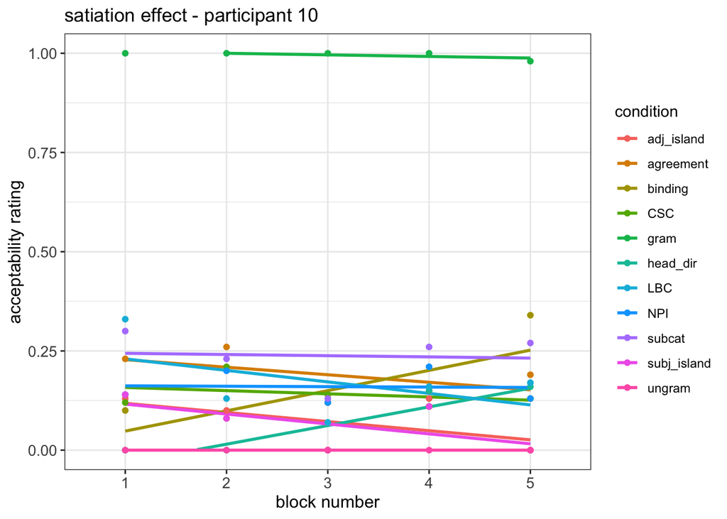

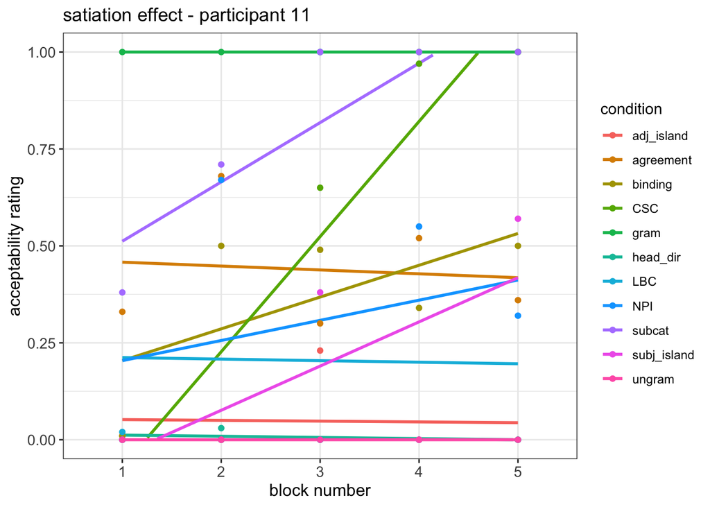

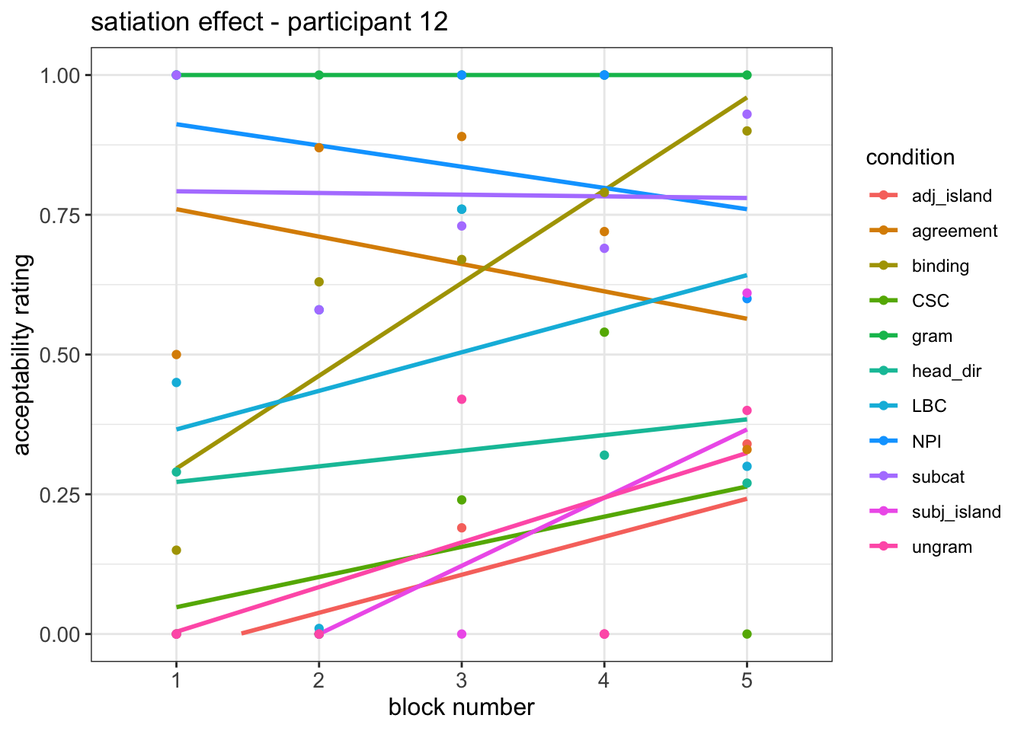

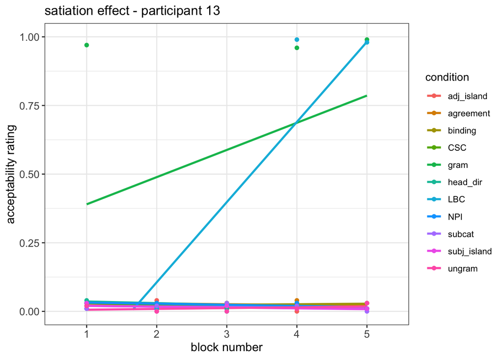

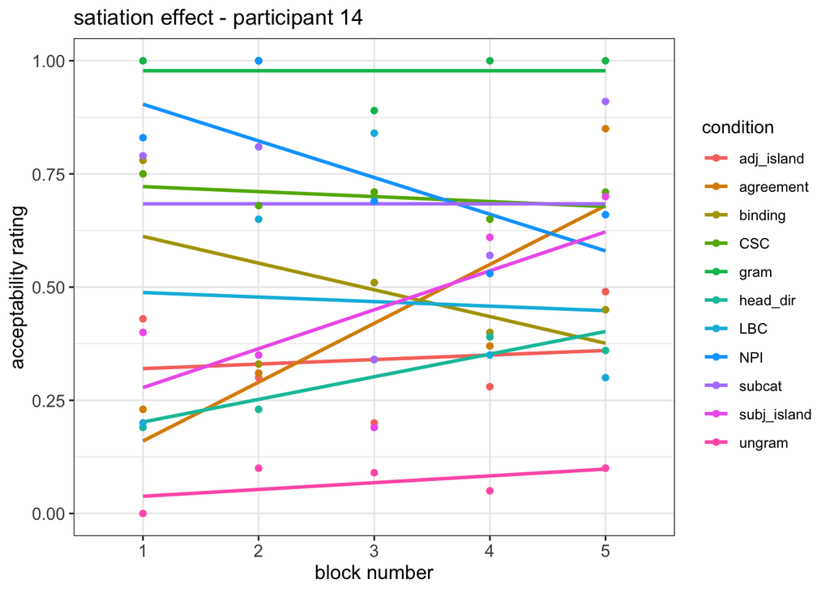

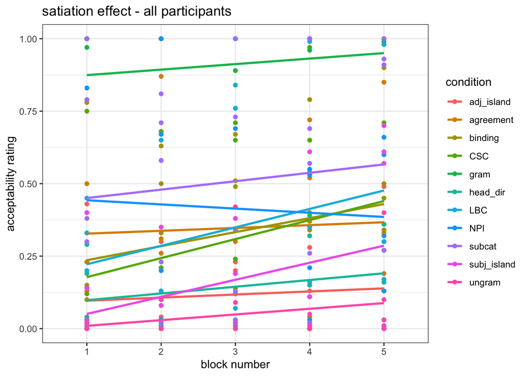

## Satiation vs individual entropies

Now we want to see if satiation rate correlates with entropy in meaning and form or confidence.

### Within participant

We will first look at plots where the satiation rate and entropies of each conditions are calcuated within participant (perhaps more justified, but less power).

#### Satiation vs Hm

First, let’s look at entropy in meaning.

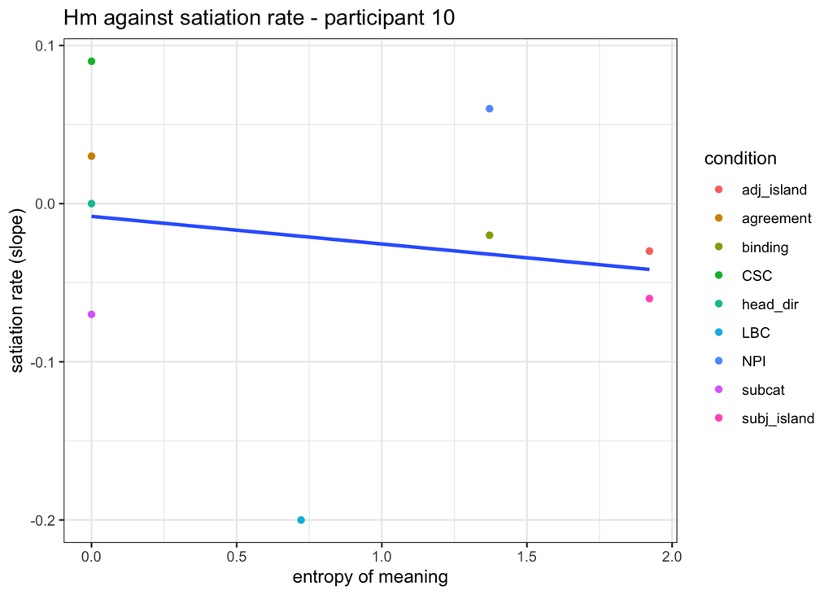

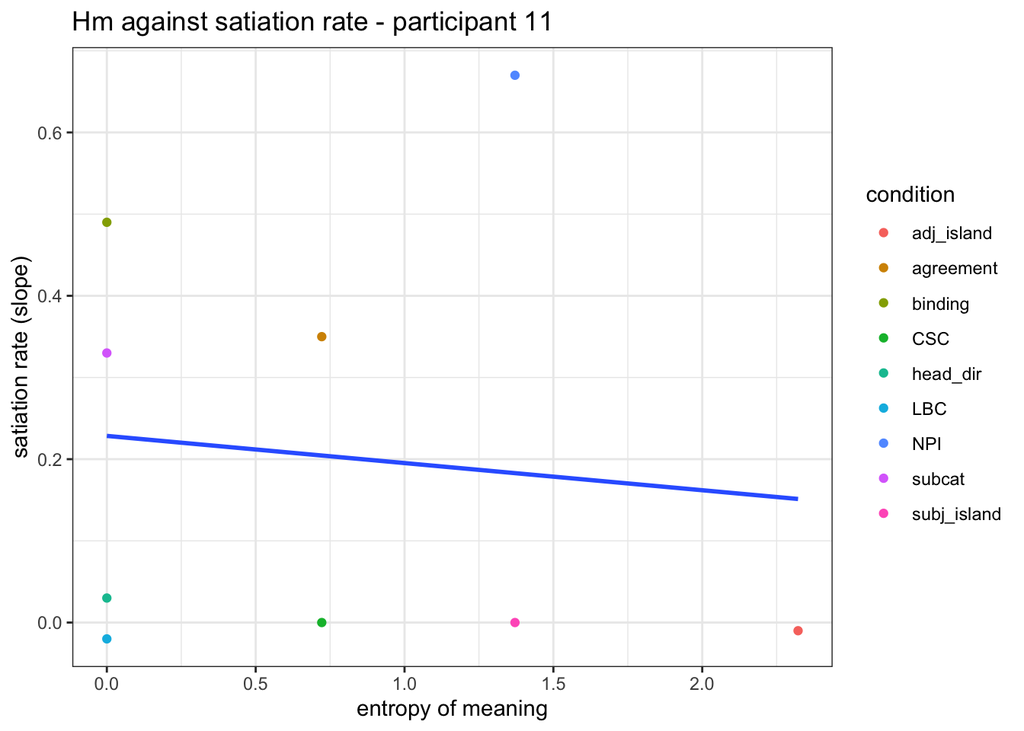

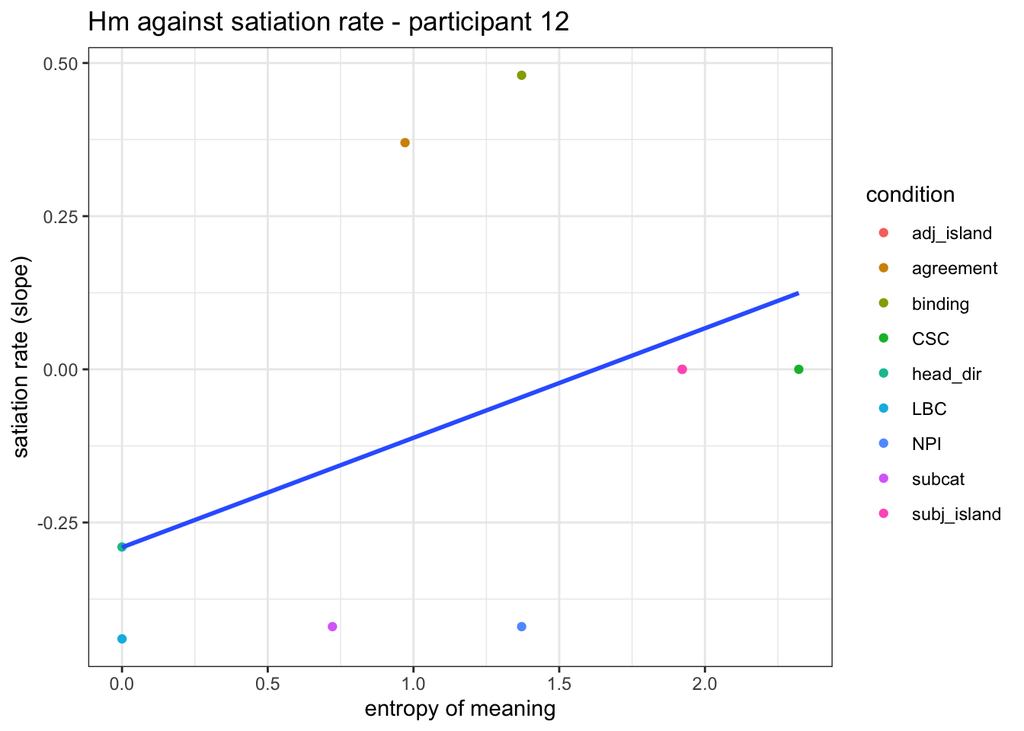

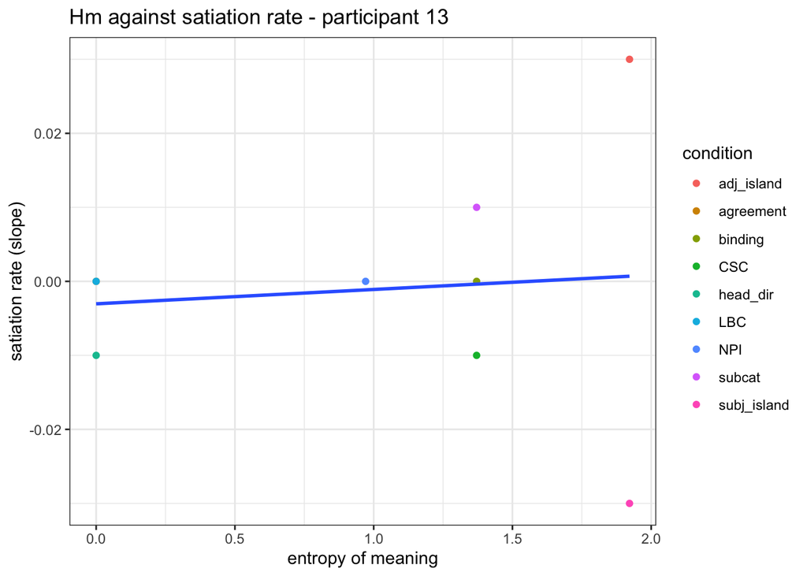

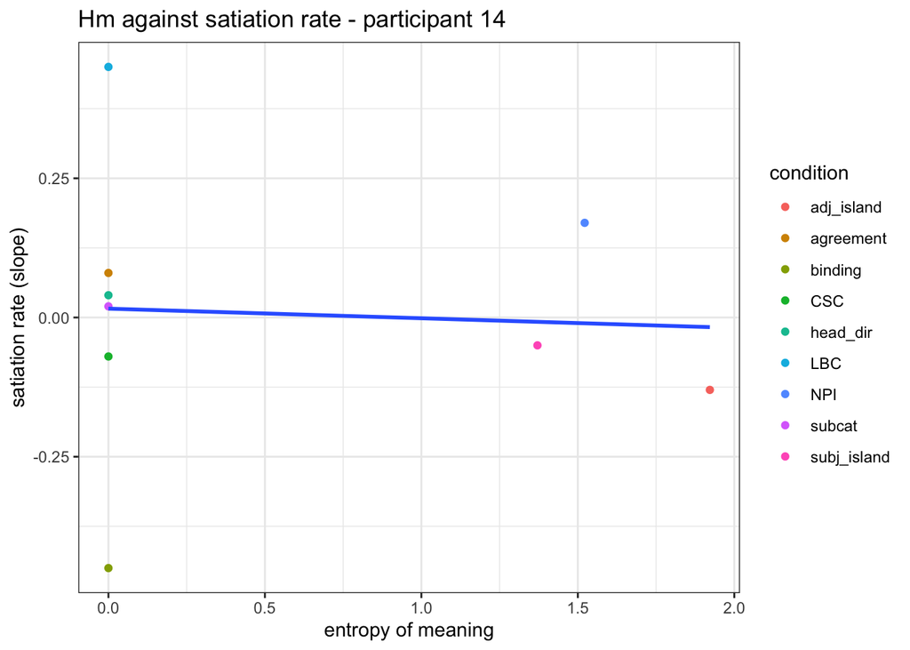

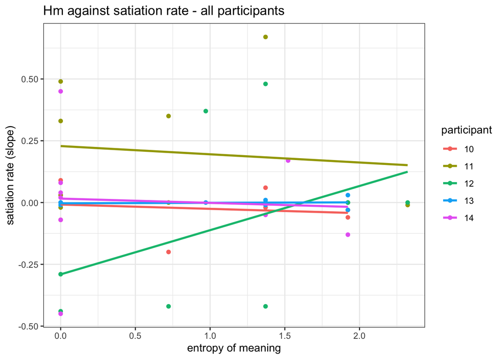

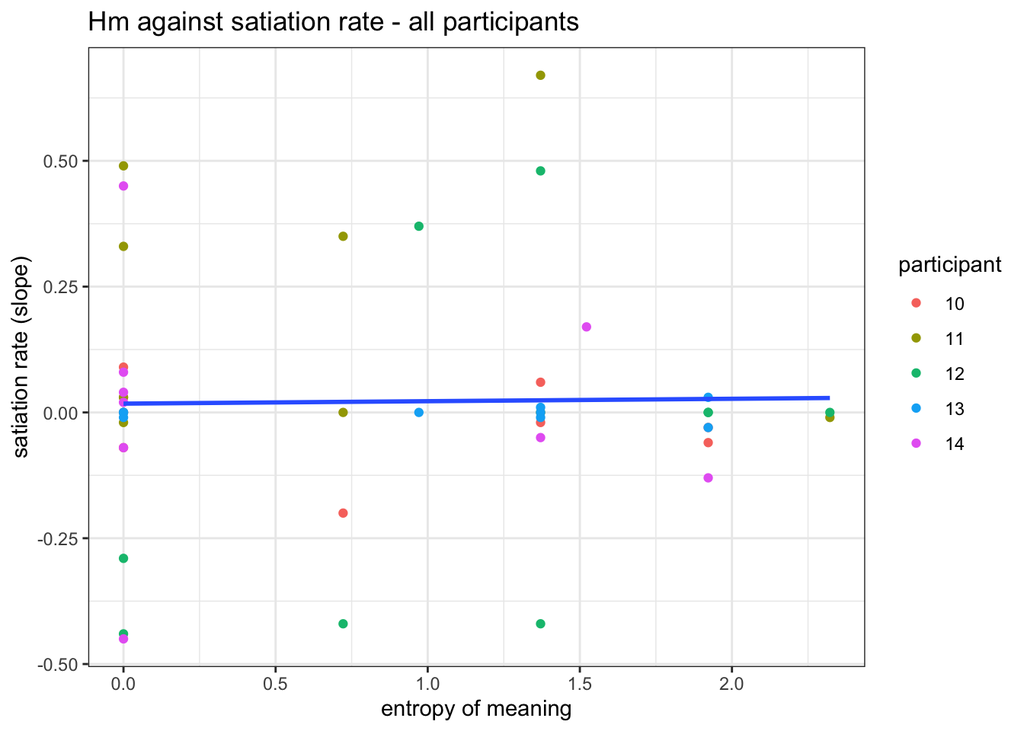

#### Satiation vs Hf

Now we will look at plots of entropy of form against satiation rate

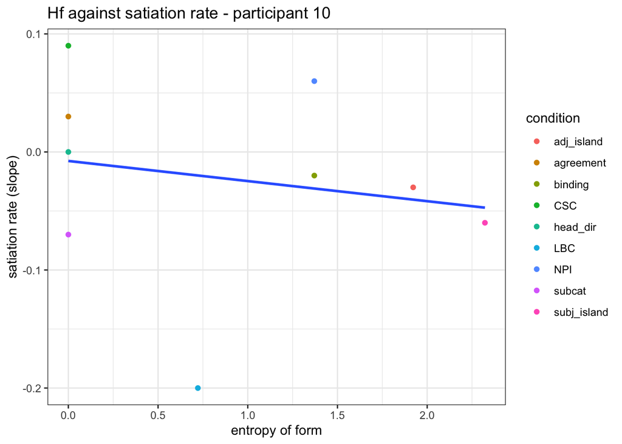

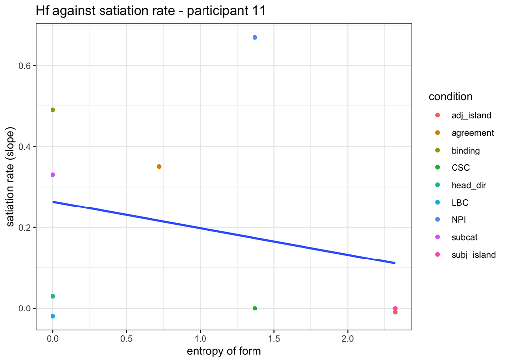

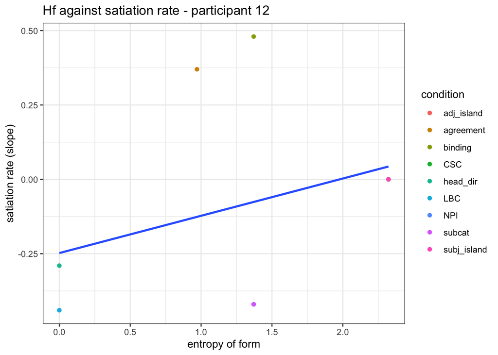

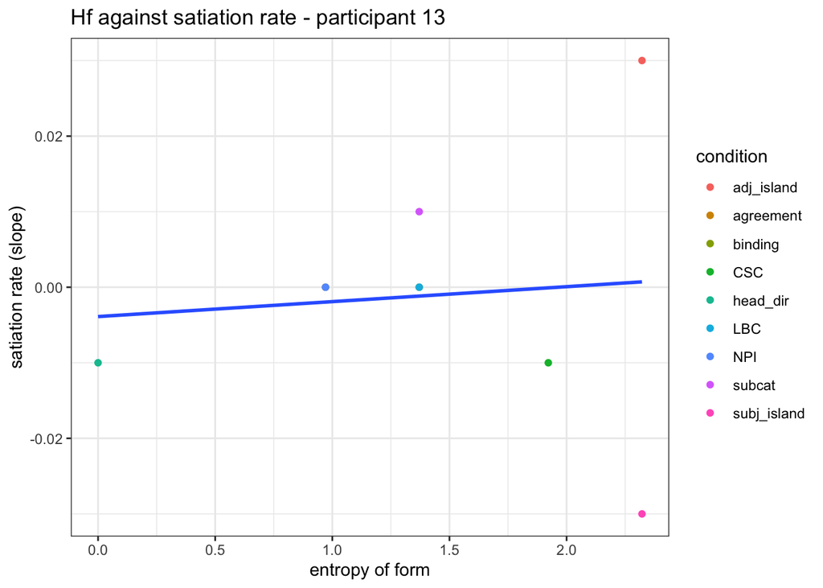

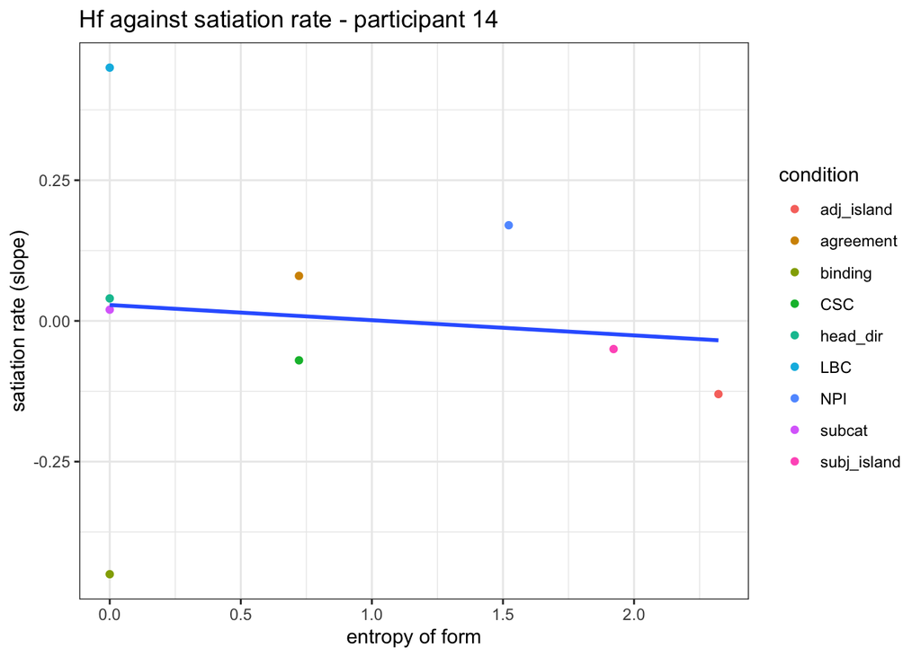

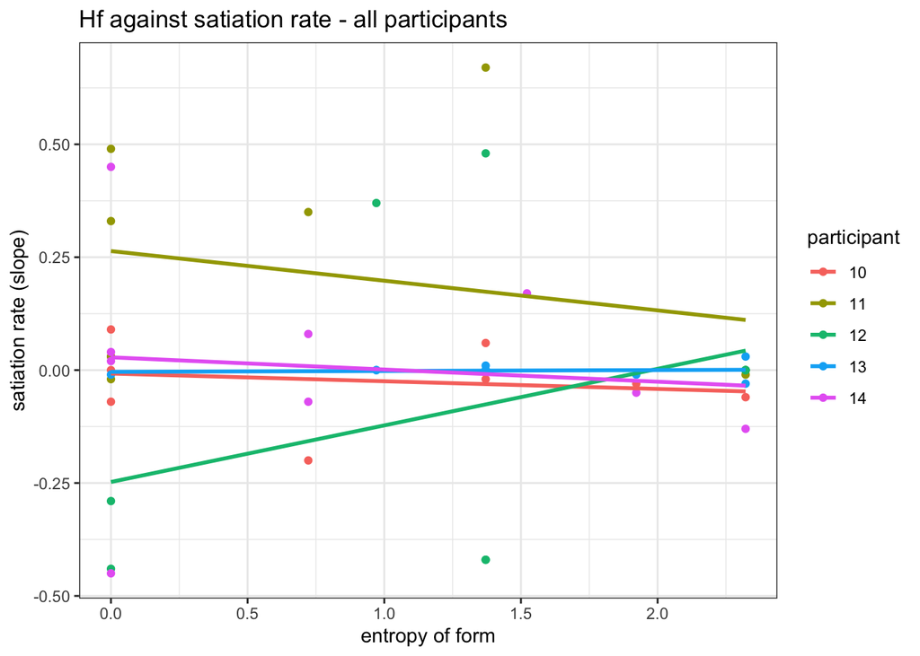

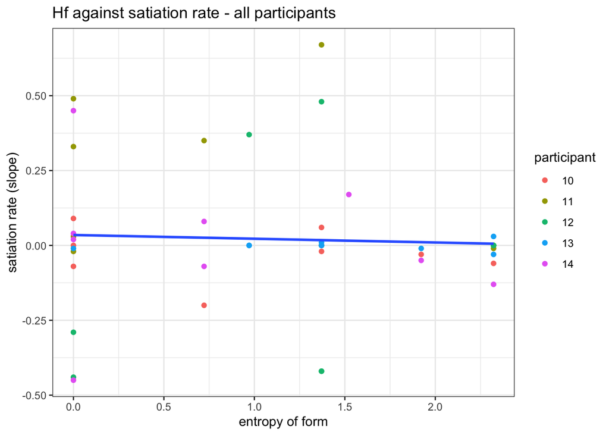

#### Satiation vs average confidence rating

Now we will see how the average confidence rating of a condition correlates with its satiation rate

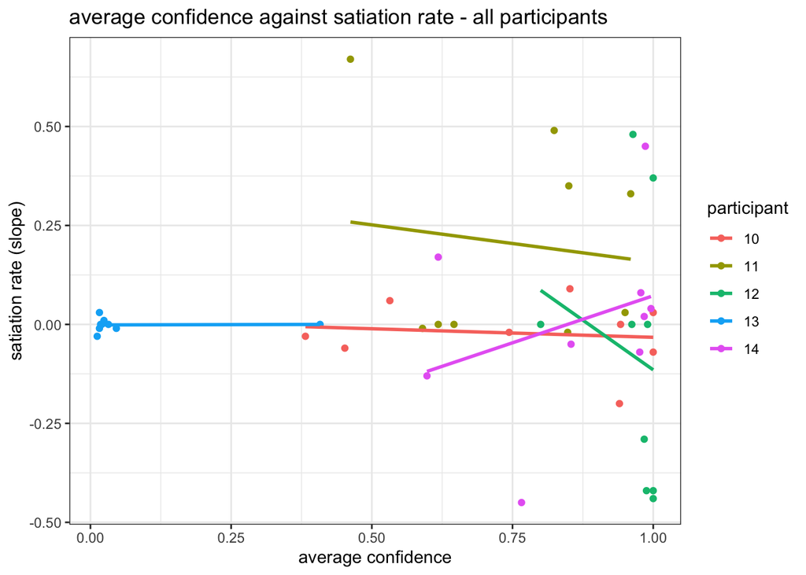

### Across participants

Now we will look at plots across participants. We will first plot Hm and Hf individually against satiation rate, this time with each data point representing the average of ratings for that condition across all participants.

#### Satiation vs Hm / Hf

```
##     condition  slope        HM        HF average_confidence
## 1  adj_island -0.028 3.4292751 3.6994706             0.5096
## 2         CSC  0.002 1.5615102 3.3532697             0.6580
## 3   agreement  0.166 0.8554508 1.5495875             0.7696
## 4     binding  0.100 1.3354313 1.2554313             0.6660
## 5    head_dir -0.046 0.0000000 0.0000000             0.7836
## 6         LBC -0.042 0.2422922 0.7195564             0.8364
## 7         NPI  0.096 2.4213153 2.4213153             0.5236
## 8      subcat -0.026 0.7195564 0.8743096             0.7936
## 9 subj_island -0.028 2.4626832 3.6732697             0.5852
```

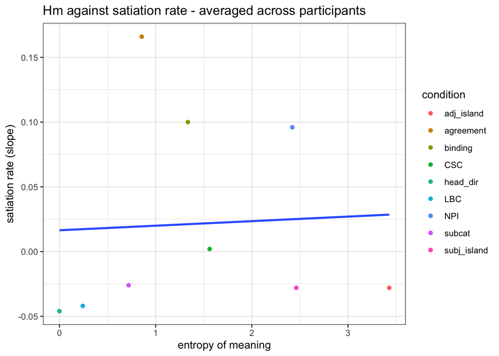

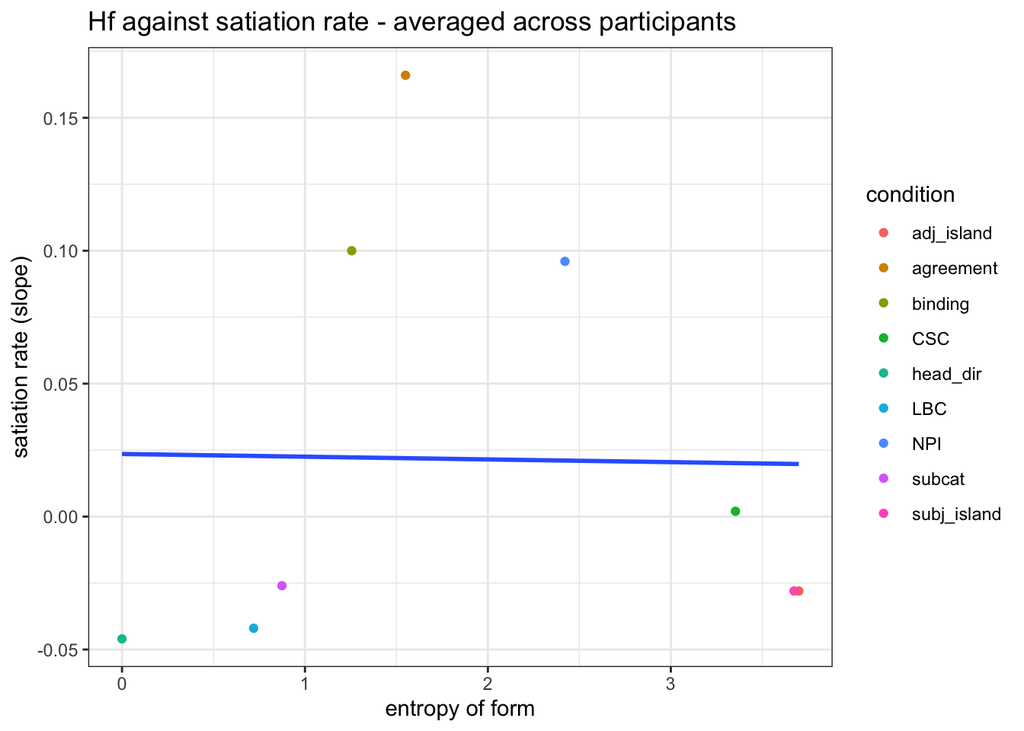

#### Satiation vs confidence

We now plot average confidence rating vs satiation rate

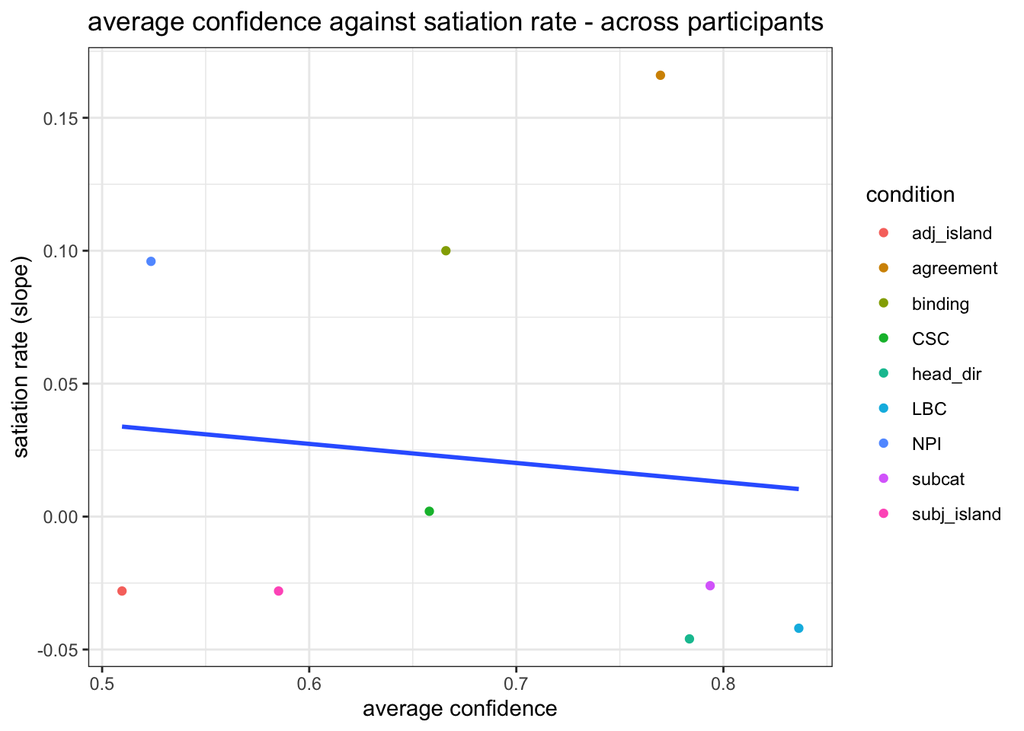

### Satiation vs change in confidence rating

Now a new graph – we will compare change in acceptability rating (satiation) to change in confidence rating

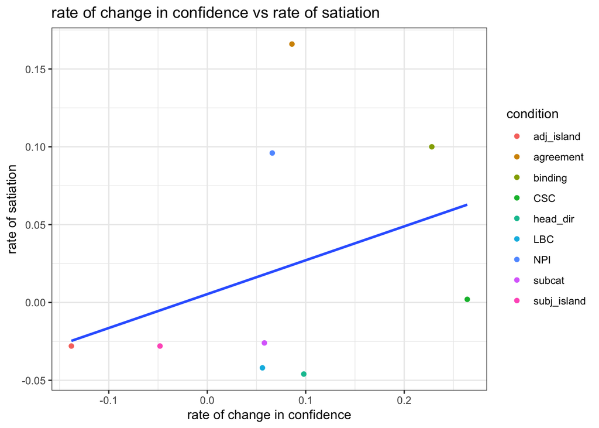

```
##
## Call:
## lm(formula = satiation_slope ~ confidence_slope, data = satiation_vs_confidence)
##
## Residuals:
##      Min       1Q   Median       3Q      Max
## -0.07268 -0.05954 -0.02290  0.04502  0.14193
##
## Coefficients:
##                  Estimate Std. Error t value Pr(>|t|)
## (Intercept)      0.005352   0.031041   0.172    0.868
## confidence_slope 0.217656   0.225273   0.966    0.366
##
## Residual standard error: 0.07836 on 7 degrees of freedom
## Multiple R-squared:  0.1177, Adjusted R-squared:  -0.008379
## F-statistic: 0.9335 on 1 and 7 DF,  p-value: 0.3661
```